# Project: Analyze Report

## Analyzing and Visualizing Data

By using the data we wrangled previously in the wrangle_act.ipynb , there are many insights that can be extracted. Here are a few ones I found interesting with their visualization.

### Insights from our wrangled data:

1. The best month for tweets is number 6 or "June" as it has the highest average in both retweets_count & favorited_count from all the months across 3 years.
2. The best category of dogs to tweet are puppies or "puppo" as they get the highest average in both retweet_count & favorite_count.
3. The breed with the highest average rating percentage is the "Clumber" breed.

### Insight #1: The best month to make tweets

Here I grouped the data by month to figure out which month has the highest average retweets and favorites across the 3 years.  
We found that month 6 or "June" had the top scores in both.

```python
master_dataset["month"] = master_dataset["timestamp"].dt.month
```

```
June (6) has the highest average favorites (15981)
```

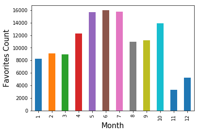

```python
month_favorite_average = master_dataset.groupby("month")["favorite_count"].mean()
month_favorite_average.plot(kind = "bar");
plt.xlabel("Month", fontdict={"fontsize": 15})
plt.ylabel("Favorites Count", fontdict={"fontsize": 15})
print(f"June (6) has the highest average favorites ({math.ceil(sorted(month_favorite_average)[-1])})")
```

```
June has the highest average retweets (4972)
```

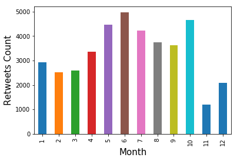

```python
month_retweet_average = master_dataset.groupby("month")["retweet_count"].mean()
month_retweet_average.plot(kind = "bar");
plt.xlabel("Month", fontdict={"fontsize": 15})
plt.ylabel("Retweets Count", fontdict={"fontsize": 15})
print(f"June has the highest average retweets ({math.ceil(sorted(month_retweet_average)[-1])})")
```

### Insight #2: The best dog category for tweets

I wanted to check which category of dogs had the top average retweets and favorites.  
The result informed us that puppies or "puppo" in the DoggoLingo had the highest in both.

```
Puppies (puppo) has the highest average favorites (22716)
```

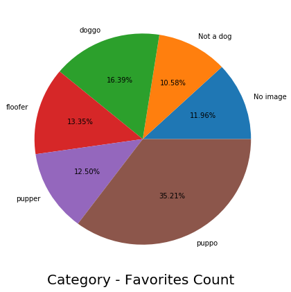

```python
category_favorite_average = master_dataset.groupby("category")["favorite_count"].mean()
category_favorite_average.plot(kind = "pie", figsize = (7, 7), autopct = "%1.2f%%");
plt.xlabel("Category - Favorites Count ", fontdict={"fontsize": 20})
plt.ylabel("", fontdict={"fontsize": 15})
print(f"Puppies (puppo) has the highest average favorites ({math.ceil(sorted(category_favorite_average)[-1])})")
```

```
Puppies (puppo) has the highest average retweets (7125)
```

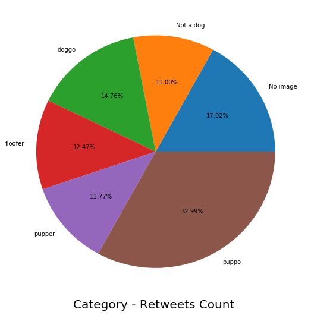

```python
category_retweet_average = master_dataset.groupby("category")["retweet_count"].mean()
category_retweet_average.plot(kind = "pie", figsize = (9, 9), autopct = "%1.2f%%");
plt.xlabel("Category - Retweets Count ", fontdict={"fontsize": 20})
plt.ylabel("", fontdict={"fontsize": 15})
print(f"Puppies (puppo) has the highest average retweets ({math.ceil(sorted(category_retweet_average)[-1])})")
```

### Insight #3: The dog breed with highest average rating

To check which dog breed did the weRateDogs page give the highest average rating to, I wrote the following code  
I found that a breed called "Clumber" had the highest with a staggering 270% !!

```python
master_dataset["probable_breed"] = master_dataset["category"]
master_dataset["rating_percentage"] = master_dataset["rating_numerator"] / master_dataset["rating_denominator"] * 100
for index, row in master_dataset.iterrows():
    if row["p1_dog"] == True:
        master_dataset.loc[index, "probable_breed"] = row["p1"]
    elif row["p2_dog"] == True:
        master_dataset.loc[index, "probable_breed"] = row["p2"]
    elif row["p3_dog"] == True:
        master_dataset.loc[index, "probable_breed"] = row["p3"]
    else:
        continue
```

```
probable_breed
Gordon Setter           117.500000
Standard Schnauzer      120.000000
Silky Terrier           120.000000
Border Terrier          121.428571
Tibetan Mastiff         122.500000
Briard                  123.333333
Saluki                  125.000000
Pomeranian              125.365854
Bouvier Des Flandres    130.000000
Clumber                 270.000000
Name: rating_percentage, dtype: float64
```

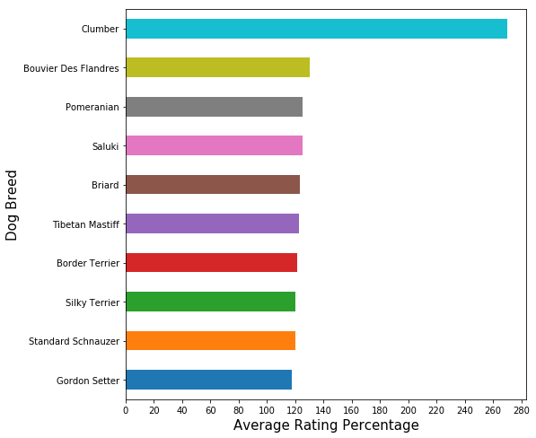

```python
top_10_ratings_average = master_dataset[(master_dataset["probable_breed"] != "Not a dog") &
                                       (master_dataset["probable_breed"] != "puppo")].groupby("probable_breed")["rating_percentage"].mean().sort_values().tail(10)
top_10_ratings_average.plot(kind = "barh", figsize = (8, 8))
plt.xticks(np.arange(0, 300, 20))
plt.xlabel("Average Rating Percentage", fontdict={"fontsize": 15})
plt.ylabel("Dog Breed", fontdict={"fontsize": 15})
top_10_ratings_average
```

### Converts Notebook to html

```python
from subprocess import call
call(['python', '-m', 'nbconvert', 'act_report.ipynb'])
```